# ST542 - Consulting Project

Brian Sugg & Chengxi Zou

2/11/2022

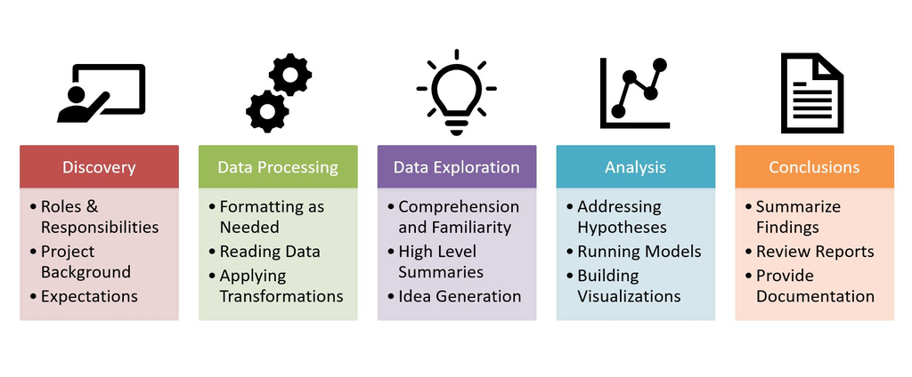

# Discovery

# Data Processing

Raw data from the research conducted in 2020 and 2021 was provided in multiple Excel files. An inventory is outlined below of the source files that were received:

- `2020 Pumpkin Results for Joy.xlsx`
  - 2020 Spacing Study
- `2020 stand count.xlsx`
  - 2020 Spacing Study Stand Counts
- `2021 Pumpkin Trial Data.xlsx`
  - 2021 Spacing Study
  - 2021 Nitrogen Study
  - 2021 Leaf Composition Study
- `2021 Bin Pumpkin Sizes.xlsx`
  - 2021 Bin Capacity Study

## Data Formatting

Each of the provided files required formatting in Excel prior to importing into R. A full step-by-step overview of the changes made within each Excel workbook is outlined further below. Generally speaking, the formatting effort focused on getting the worksheets into a table form. This included tasks such as removing unnecessary blank rows and columns, ensuring categorical values were consistently spelled and spaced (“10 x 1” rather than “10x 1”), along with other minor changes to assist with a clean import to R.

### `2020 Pumpkin Results for Joy.xlsx`

This file contained the 2020 spacing study data, consisting of three worksheets total, with one worksheet for each of the three metrics that were recorded during the harvest (weight, length, diameter). The worksheet inventory included:

- `Spacing Weight`
- `Spacing Length`
- `Spacing Diameter`

The below formatting steps were followed for each of the three worksheets:

1. Removed empty rows and empty columns from the top and the left of the main data frame
   - Resulted in all column names moving up to row 1
2. Removed empty rows between records that were separating `reps`
3. Inserted 1 column at column D position as `Spacing` to hold a concatenation of the `Row Distance` and `In Row Distance` columns, to match the same presentation of the `Spacing` variable in the 2021 data
   - Formula = `CONCATENATE($E2," x ",$F2)` and apply down entire column
4. Copied the new `Spacing` column D and pasted back as values only to remove formula dependence on `Row Distance` and `In Row Distance`
5. Deleted the `Row Distance` and `In Row Distance` columns after concatenation
6. Checked `Green Fruit` column E to ensure all values were evenly spaced by “,” (“comma space”) for parsing during the import process
7. Repeated the above steps 1 - 6 for the other two worksheets

Finally, the file was renamed to `2020pumpkinData.xlsx` after formatting for easy future reference.

#### Preview Before Formatting

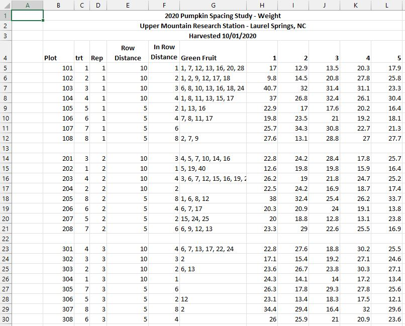

2020 Pumpkin Results for Joy.xlsx

#### Preview After Formatting

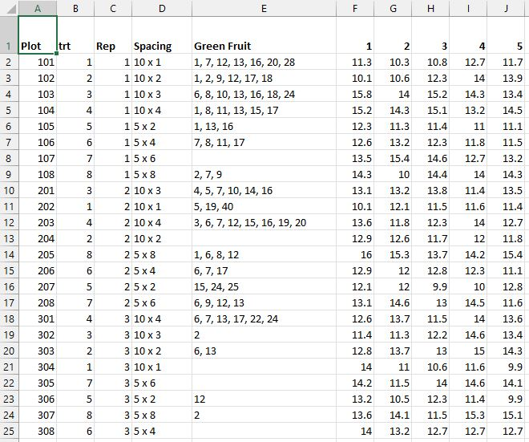

2020pumpkinData.xlsx

### `2020 stand count.xlsx`

This file contained the stand count data from the 2020 spacing study, which was not part of the original file `2020 Pumpkin Results for Joy.xlsx`. The worksheet inventory included:

- `Sheet1`

The below formatting steps were followed:

1. Removed empty rows and empty columns from the top and the left of the main data frame
   - Resulted in all column names moving up to row 1

Finally, the file was renamed to `2020standCount.xlsx` after formatting for easy future reference.

### `2021 Pumpkin Trial Data.xlsx`

This file contained the 2021 spacing study, nitrogen study, and leaf composition study data, consisting of nine worksheets total, with one worksheet for each of the three metrics that were recorded during the harvest (weight, length, diameter) for each of the three studies. The worksheet inventory included:

- `Spacing Weights (lbs)`
- `Spacing Lengths (inches)`
- `Spacing Diameters (inches)`
- `Nitrogen Weights (lbs)`
- `Nitrogen Lengths (inches)`
- `Nitrogen Diameters (inches)`
- `Leaf Analysis Nitrogen (%)`
- `Leaf Analysis Phosphorus (%)`
- `Leaf Analysis Potassium (%)`

#### Spacing Study

The below formatting steps were followed for each of the three worksheets for the spacing study:

1. Removed empty rows and empty columns from the top and the left of the main data frame
   - Resulted in all column names moving up to row 1
2. Removed empty rows between records that were separating `reps`
3. Checked `Spacing` column F to ensure all values were evenly spaced for consistent categorical values
   - Example: Adjusted `5x 8` to `5 x 8`
4. Checked `Green Fruit` column G to ensure all values were evenly spaced by “,” (“comma space”) for parsing during the import process
5. Repeated the above steps 1 - 4 for the other two spacing study worksheets

Finally, the file was renamed to `2021pumpkinData.xlsx` after formatting for easy future reference.

#### Preview Before Formatting

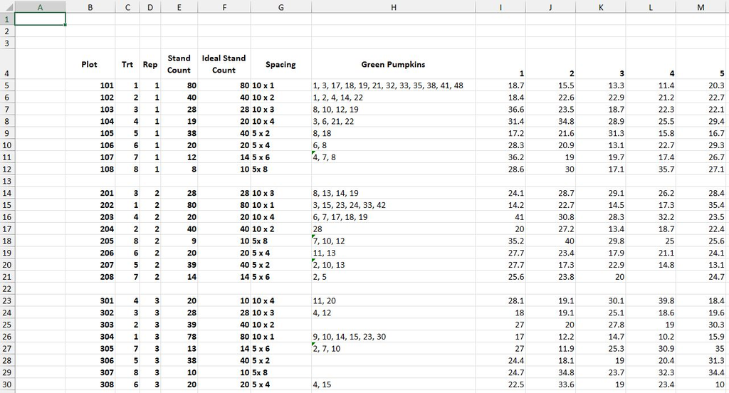

2021 Pumpkin Trial Data.xlsx

#### Preview After Formatting

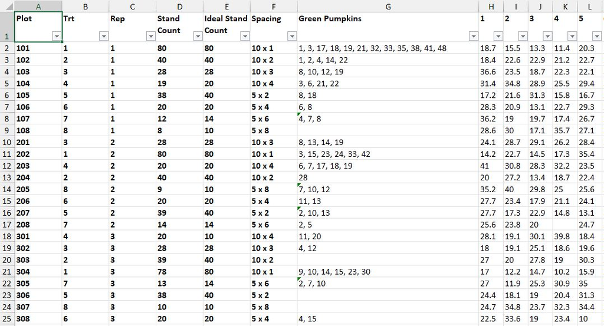

2021pumpkinData.xlsx

## Data Import

### Spacing Study

#### 2020 Data

```r
# Read sheet with WEIGHTS, transform from wide to tall, remove NA
# records
spacingWeight <- read_excel(path = "2020pumpkinData.xlsx", sheet = "Spacing Weight")
spacingWeight <- gather(spacingWeight, key = "Pumpkin", value = "Weight",
    6:53)
spacingWeight <- subset(spacingWeight, !is.na(Weight))
# Rename columns
names(spacingWeight) <- c("plot", "treatment", "rep", "spacingDim", "greenPumpkins",
    "pumpkinNum", "weight")
# Create unique identifier for each pumpkin
spacingWeight <- mutate(spacingWeight, year = "2020")
spacingWeight <- mutate(spacingWeight, pumpkinID = paste0(year, "-", "S",
    "-", plot, "-", pumpkinNum))

# Read sheet with LENGTHS, transform from wide to tall, remove NA
# records
spacingLength <- read_excel(path = "2020pumpkinData.xlsx", sheet = "Spacing Length")
spacingLength <- gather(spacingLength, key = "Pumpkin", value = "Length",
    6:52)
spacingLength <- subset(spacingLength, !is.na(Length))
# Rename columns
names(spacingLength) <- c("plot", "treatment", "rep", "spacingDim", "greenPumpkins",
    "pumpkinNum", "length")
# Create unique identifier for each pumpkin and assign crop year
spacingLength <- mutate(spacingLength, year = "2020")
spacingLength <- mutate(spacingLength, pumpkinID = paste0(year, "-", "S",
    "-", plot, "-", pumpkinNum))

# Read sheet with DIAMETERS, transform from wide to tall, remove NA
# records
spacingDiameter <- read_excel(path = "2020pumpkinData.xlsx", sheet = "Spacing Diameter")
spacingDiameter <- gather(spacingDiameter, key = "Pumpkin", value = "Diameter",
    6:52)
spacingDiameter <- subset(spacingDiameter, !is.na(Diameter))
# Rename columns
names(spacingDiameter) <- c("plot", "treatment", "rep", "spacingDim", "greenPumpkins",
    "pumpkinNum", "diameter")
# Create unique identifier for each pumpkin and assign crop year
spacingDiameter <- mutate(spacingDiameter, year = "2020")
spacingDiameter <- mutate(spacingDiameter, pumpkinID = paste0(year, "-",
    "S", "-", plot, "-", pumpkinNum))

# Join all spacing metrics in one raw table for quality checks
spacingDataRaw2020 <- inner_join(spacingWeight, spacingLength)
spacingDataRaw2020 <- inner_join(spacingDataRaw2020, spacingDiameter)
# Read sheet with stand count data
spacingStand <- read_excel(path = "2020standCount.xlsx", sheet = "Sheet1")
# Rename columns
names(spacingStand) <- c("treatment", "spacingDim", "plot", "standCountIdeal",
    "standCount")
# Remove measurement abbreviation for feet (')
spacingStand$spacingDim <- str_remove_all(spacingStand$spacingDim, "'")

# Join stand counts to spacing metrics
spacingDataRaw2020 <- left_join(spacingDataRaw2020, spacingStand)
# Arrange columns for presentation of final table for spacing data
spacingDataRaw2020 <- select(spacingDataRaw2020, c(1, 2, 3, 13, 12, 4,
    5, 6, 7, 8, 9, 10, 11))

# Create clean table for further transformations
spacingData2020 <- as_tibble(spacingDataRaw2020)

# Remove bad pumpkins ... NEED TO CONFIRM WITH CLIENT
spacingData2020 <- subset(spacingData2020, weight != "rotten")
```

#### 2021 Data

Check workbook names and worksheet names for each of the 3 read_excel functions.

```r
# Read sheet with WEIGHTS, transform from wide to tall, remove NA
# records
spacingWeight <- read_excel(path = "2021pumpkinData.xlsx", sheet = "Spacing Weights (lbs)")
spacingWeight <- gather(spacingWeight, key = "Pumpkin", value = "Weight",
    8:55)
spacingWeight <- subset(spacingWeight, !is.na(Weight))
# Rename columns
names(spacingWeight) <- c("plot", "treatment", "rep", "standCount", "standCountIdeal",
    "spacingDim", "greenPumpkins", "pumpkinNum", "weight")
# Create unique identifier for each pumpkin
spacingWeight <- mutate(spacingWeight, year = "2021")
spacingWeight <- mutate(spacingWeight, pumpkinID = paste0(year, "-", "S",
    "-", plot, "-", pumpkinNum))

# Read sheet with LENGTHS, transform from wide to tall, remove NA
# records
spacingLength <- read_excel(path = "2021pumpkinData.xlsx", sheet = "Spacing Lengths (inches)")
spacingLength <- gather(spacingLength, key = "Pumpkin", value = "Length",
    8:55)
spacingLength <- subset(spacingLength, !is.na(Length))
# Rename columns
names(spacingLength) <- c("plot", "treatment", "rep", "standCount", "standCountIdeal",
    "spacingDim", "greenPumpkins", "pumpkinNum", "length")
# Create unique identifier for each pumpkin and assign crop year
spacingLength <- mutate(spacingLength, year = "2021")
spacingLength <- mutate(spacingLength, pumpkinID = paste0(year, "-", "S",
    "-", plot, "-", pumpkinNum))

# Read sheet with DIAMETERS, transform from wide to tall, remove NA
# records
spacingDiameter <- read_excel(path = "2021pumpkinData.xlsx", sheet = "Spacing Diameters (inches)")
spacingDiameter <- gather(spacingDiameter, key = "Pumpkin", value = "Diameter",
    8:55)
spacingDiameter <- subset(spacingDiameter, !is.na(Diameter))
# Rename columns
names(spacingDiameter) <- c("plot", "treatment", "rep", "standCount", "standCountIdeal",
    "spacingDim", "greenPumpkins", "pumpkinNum", "diameter")
# Create unique identifier for each pumpkin and assign crop year
spacingDiameter <- mutate(spacingDiameter, year = "2021")
spacingDiameter <- mutate(spacingDiameter, pumpkinID = paste0(year, "-",
    "S", "-", plot, "-", pumpkinNum))

# Join all spacing metrics in one raw table for quality checks
spacingDataRaw2021 <- inner_join(spacingWeight, spacingLength)
spacingDataRaw2021 <- inner_join(spacingDataRaw2021, spacingDiameter)
# Create clean table for further transformations
spacingData2021 <- as_tibble(spacingDataRaw2021)
```

## Data Transformation

```r
# Stack the 2020 and 2021 data sets into one tibble
spacingData <- rbind(spacingData2020, spacingData2021)

# Format variables
spacingData$plot <- as.factor(spacingData$plot)
spacingData$treatment <- as.factor(spacingData$treatment)
spacingData$rep <- as.factor(spacingData$rep)
spacingData$pumpkinNum <- as.numeric(spacingData$pumpkinNum)
spacingData$year <- as.factor(spacingData$year)

# Create variable for pumpkin color, populate based on conditional
# statement, and format
spacingData <- mutate(spacingData, color = "unknown")
for (i in 1:nrow(spacingData)) {
    spacingData[i, 14] <- if_else(spacingData[i, 8] %in% sapply(strsplit(as.character(spacingData[i,
        7]), split = ", "), function(x) as.numeric(x)), "Green", "Orange")
}
spacingData$color <- as.factor(spacingData$color)

# Create variable for spacing area and transform spacing variables
# factors
spacingData <- mutate(spacingData, spacingArea = sapply(strsplit(as.character(spacingDim),
    split = " x "), function(x) prod(as.numeric(x))))
spacingData$spacingArea <- as.factor(spacingData$spacingArea)
spacingData$spacingDim <- as.character(spacingData$spacingDim)
spacingData$length <- as.numeric(spacingData$length)

# Create variable for realized ideal stand count percentage
spacingData <- mutate(spacingData, standCountIdealPct = standCount/standCountIdeal)

# Create variable for volume spacingData <-
# mutate(spacingData,volumeSphere=(4/3)*pi*(diameter/2)^3)
spacingData <- mutate(spacingData, volumeEllipsoid = (4/3) * pi * (diameter/2) *
    (diameter/2) * (length/2))

# Arrange columns for presentation of final table for spacing data
spacingData <- select(spacingData, c(11, 10, 1, 3, 2, 8, 15, 6, 4, 5, 16,
    14, 9, 12, 13, 17))

# Split spacingDim for betweenRow and inRow columns
spacingData <- separate(spacingData, spacingDim, into = c("betweenRow",
    "inRow"), sep = " x ", remove = FALSE)
spacingData$spacingDim <- as.factor(spacingData$spacingDim)
spacingData$betweenRow <- as.factor(spacingData$betweenRow)
spacingData$inRow <- as.factor(spacingData$inRow)

# Provide structure of transformed variables with data preview
str(spacingData)
```

```
## tibble [1,259 x 18] (S3: tbl_df/tbl/data.frame)
##  $ pumpkinID         : chr [1:1259] "2020-S-101-1" "2020-S-102-1" "2020-S-103-1" "2020-S-104-1" ...
##  $ year              : Factor w/ 2 levels "2020","2021": 1 1 1 1 1 1 1 1 1 1 ...
##  $ plot              : Factor w/ 32 levels "101","102","103",..: 1 2 3 4 5 6 7 8 9 10 ...
##  $ rep               : Factor w/ 4 levels "1","2","3","4": 1 1 1 1 1 1 1 1 2 2 ...
##  $ treatment         : Factor w/ 8 levels "1","2","3","4",..: 1 2 3 4 5 6 7 8 3 1 ...
##  $ pumpkinNum        : num [1:1259] 1 1 1 1 1 1 1 1 1 1 ...
##  $ spacingArea       : Factor w/ 4 levels "10","20","30",..: 1 2 3 4 1 2 3 4 3 1 ...
##  $ spacingDim        : Factor w/ 8 levels "10 x 1","10 x 2",..: 1 2 3 4 5 6 7 8 3 1 ...
##  $ betweenRow        : Factor w/ 2 levels "10","5": 1 1 1 1 2 2 2 2 1 1 ...
##  $ inRow             : Factor w/ 6 levels "1","2","3","4",..: 1 2 3 4 2 4 5 6 3 1 ...
##  $ standCount        : num [1:1259] 79 40 28 20 40 20 14 10 28 80 ...
##  $ standCountIdeal   : num [1:1259] 80 40 28 20 40 20 14 10 28 80 ...
##  $ standCountIdealPct: num [1:1259] 0.988 1 1 1 1 ...
##  $ color             : Factor w/ 2 levels "Green","Orange": 1 1 2 1 1 2 2 2 2 2 ...
##  $ weight            : chr [1:1259] "17" "9.8" "40.7" "37" ...
##  $ length            : num [1:1259] 11.1 9.3 16.1 13.5 11.5 11.4 12.7 12.9 12.3 10.1 ...
##  $ diameter          : num [1:1259] 11.3 10.1 15.8 15.2 12.3 12.6 13.5 14.3 13.1 10.1 ...
##  $ volumeEllipsoid   : num [1:1259] 742 497 2104 1633 911 ...
```

```r
spacingData
```

```
## # A tibble: 1,259 x 18
##    pumpkinID year  plot  rep   treatment pumpkinNum spacingArea spacingDim
##    <chr>     <fct> <fct> <fct> <fct>          <dbl> <fct>       <fct>
##  1 2020-S-1~ 2020  101   1     1                  1 10          10 x 1
##  2 2020-S-1~ 2020  102   1     2                  1 20          10 x 2
##  3 2020-S-1~ 2020  103   1     3                  1 30          10 x 3
##  4 2020-S-1~ 2020  104   1     4                  1 40          10 x 4
##  5 2020-S-1~ 2020  105   1     5                  1 10          5 x 2
##  6 2020-S-1~ 2020  106   1     6                  1 20          5 x 4
##  7 2020-S-1~ 2020  107   1     7                  1 30          5 x 6
##  8 2020-S-1~ 2020  108   1     8                  1 40          5 x 8
##  9 2020-S-2~ 2020  201   2     3                  1 30          10 x 3
## 10 2020-S-2~ 2020  202   2     1                  1 10          10 x 1
## # ... with 1,249 more rows, and 10 more variables: betweenRow <fct>,
## #   inRow <fct>, standCount <dbl>, standCountIdeal <dbl>,
## #   standCountIdealPct <dbl>, color <fct>, weight <chr>, length <dbl>,
## #   diameter <dbl>, volumeEllipsoid <dbl>
```

```r
# Export R data object to Excel for client review
write_xlsx(spacingData, "spacingData.xlsx")
```

# Data Exploration

## Plots and Charts

### Spacing Study

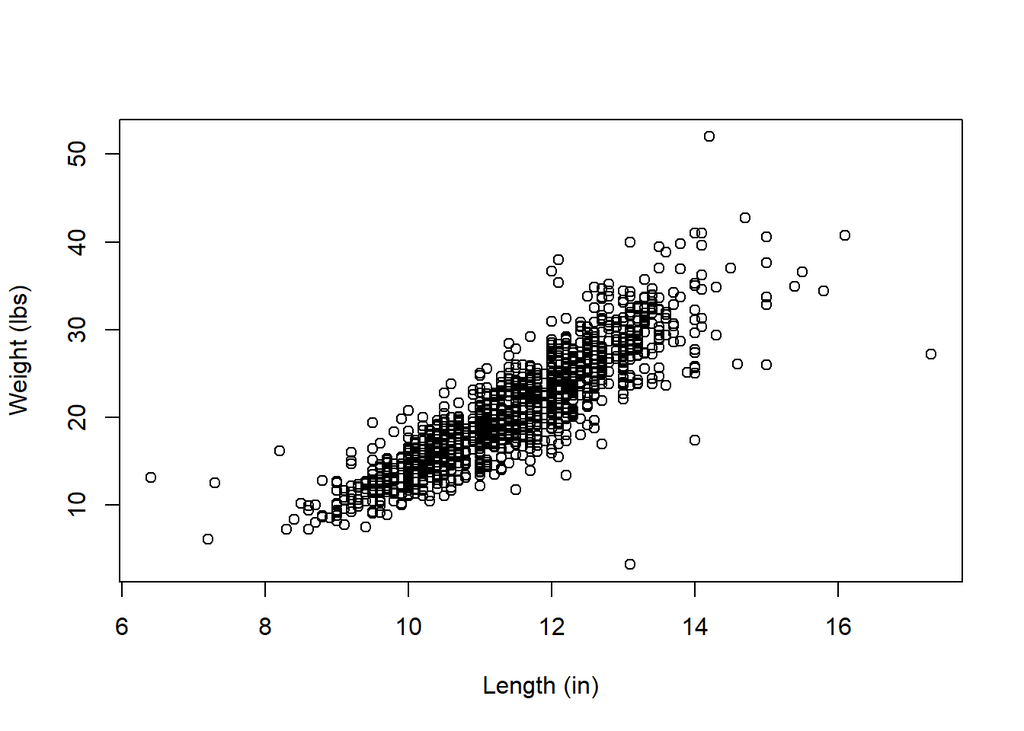

```r
# Scatter plot of weight vs length
plot(spacingData$length, spacingData$weight, xlab = "Length (in)", ylab = "Weight (lbs)")
```

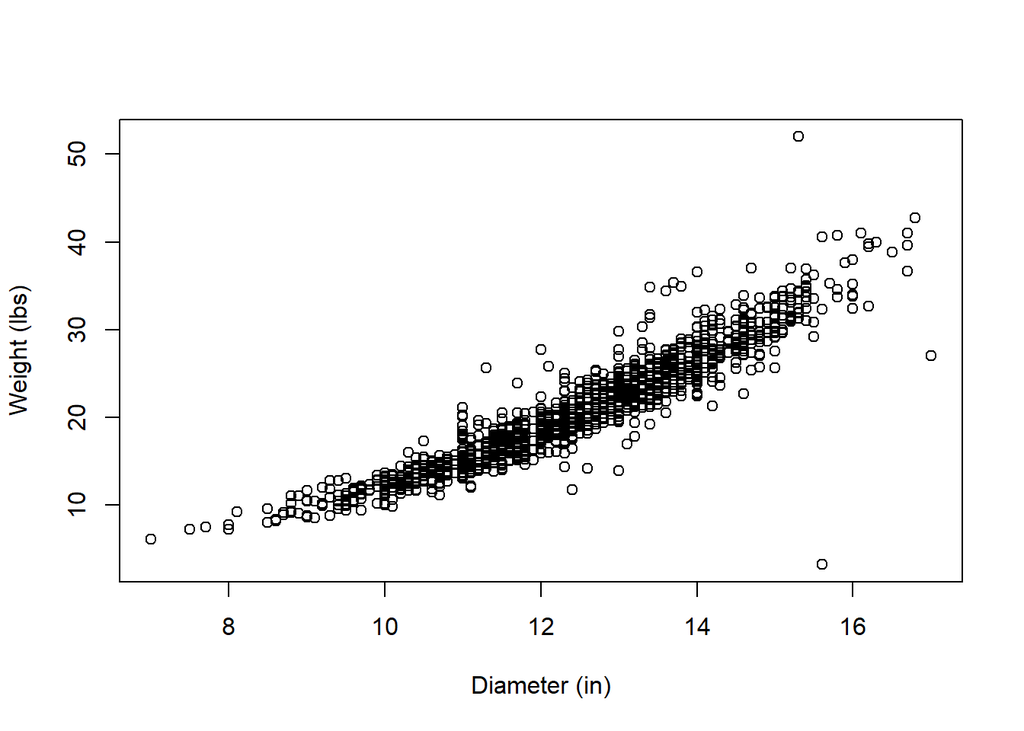

```r
# Scatter plot of weight vs diameter
plot(spacingData$diameter, spacingData$weight, xlab = "Diameter (in)",
    ylab = "Weight (lbs)")
```

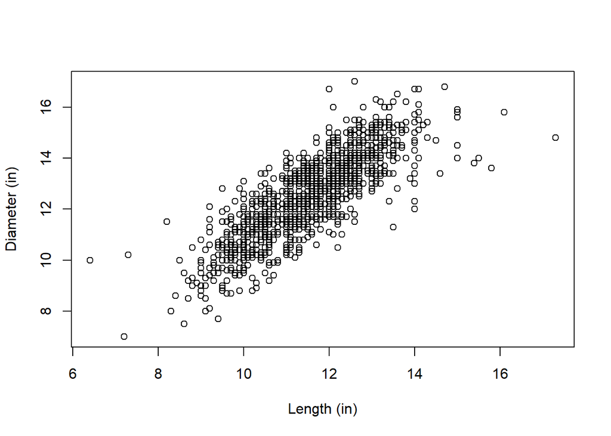

```r
# Scatter plot of diameter vs length
plot(spacingData$length, spacingData$diameter, xlab = "Length (in)", ylab = "Diameter (in)")
```

```r
# Boxplot by spacing dimension ggplot(spacingData, aes(x=spacingDim,
# y=weight, fill=spacingDim)) + geom_boxplot(varwidth = TRUE,
# alpha=0.2) + theme(legend.position='none')

# Boxplot by spacing area ggplot(spacingData, aes(x=spacingArea,
# y=weight, fill=spacingArea)) + geom_boxplot(varwidth = TRUE,
# alpha=0.2) + theme(legend.position='none')
```

# Conclusions